# Part II - (Ford go bike presentation)

## by (Fahd Ashraf)

## Investigation Overview

> What is the key behavioral differences bteween Subscribers and Customers?, how we achieved an answer for that question lies in the next slides

## Dataset Overview

> our dataset contain 183412 instances with 18 features and it discribes certain properties of each ride

## (Visualization 1)

> it is important to know what age group is dominating the use of our bikes and we have discovered that our users peak at 30 to 40 years range with a spread from 20 to 50 years

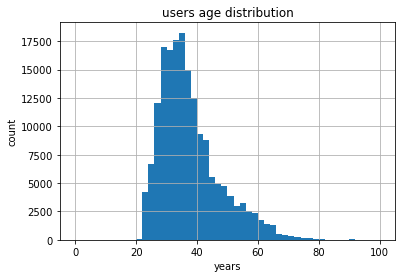

## (Visualization 2)

> now when we see how much do people ride our bikes for we found that the most rides from a range of 5 minutes to 15 minutes

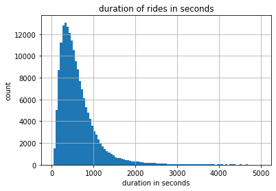

## (Visualization 3)

> now to differentiate between subscribers and customers we need to find how they use the bikes diffrently and so after our analysis we now know that subscribers tend to not use their bikes during the weekends

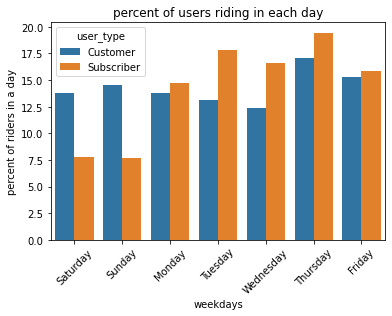

## (Visualization 4)

> Also we have figured out that on a daily basis customers' average ride is longer than that of subscribers, and it peakes in the weekednds

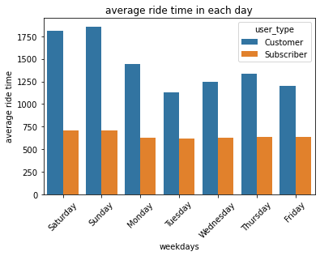